# Master cleaning of Meta-Analysis data

# Benin

```r
### here is fix for accents TO DO
  #
  # ben$m11 <- gsub("C(", "?", ben$m11)
  # table(ben$m11)

## work on main survey dataset
# rename key variables
  ben <- ben %>% mutate(treat = 1*(commonarm==1 & public==0),
                        treat1 = commonarm,
                        treat2 = public,
                        nij = N)

# generate country identifier, and block fixed effects variable
  ben %<>%
    mutate(ctry = "ben",
           fe = paste(ctry, as.factor(blockid), sep = "."),
           cl = paste(fe, as.factor(quartier), sep = "."),
           ma_id = paste(cl, seq.int(nrow(ben)), sep = "."))

## recode covariates
# m5 - effort
  ben %<>% mutate(m5 = dplyr::recode(m5,
                        "Beaucoup plus" = 4,
                        "Un peu plus" = 3,
                        "Un peu moins" = 2,
                        "Beaucoup moins" = 1))

# m6 - honesty
  ben %<>% mutate(m6 = dplyr::recode(m6,
                        "Tr?s surpris" = 1,
                        "Assez surpris" = 2,
                        "Pas tr?s surpris" = 3,
                        "Pas du tout surpris" = 4))

# m7 - criteria [2 steps]
  ben %<>%
    mutate(m7 = case_when(
              grepl("ethni", m7) ~ 1,
              grepl("famille", m7) ~ 2,
              grepl("quart", m7) ~ 3,
              grepl("perform", m7) ~ 4,
              grepl("capacit", m7) ~ 5,
              grepl("honn", m7) ~ 6,
              grepl("chef", m7) ~ 7),
           m7id = case_when(
              m7==1 ~ 1,
              m7 > 1 ~ 0),
           m7pben = case_when(
              m7==2 ~ 1,
              is.na(m7)==F ~ 0),
           m7cben = case_when(
              m7==3 ~ 1,
              is.na(m7)==F ~ 0),
           m7pol = case_when(
              m7==4 ~ 1,
              is.na(m7)==F ~ 0),
           m7eff = case_when(
              m7==5 ~ 1,
              is.na(m7)==F ~ 0),
           m7char = case_when(
              m7==6 ~ 1,
              is.na(m7)==F ~ 0),
           m7end = case_when(
              m7==7 ~ 1,
              is.na(m7)==F ~ 0)) %>%
    dplyr::select(-m7)

# m8 - backlash

# m9 - priors # remember to check info scale
  ben %<>% mutate(m9 = dplyr::recode(m9,
                        "Much worse" = 4,
                        "A little worse" = 3,
                        "A little better" = 2,
                        "Much better" = 1))

# m10 - good news

# m11 - certainty [concern: ACCENTS CAUSING PROBLEMS!!!]
  ben %<>% mutate(m11 = dplyr::recode(m11,
                        "Tr?s confiant" = 1,
                        "Confiant" = 2,
                        "Pas tr?s confiant" = 3,
                        "Pas du tout confiant" = 4))

# m12 - cluster priors

# m13 - gender
  ben$m13 <- (ben$m13=="femme")*1

# m14 - age

# m15 - coethnic

# m16 - cogender # 3 NAs

# m17 - educ  # 24 NAs

# m18 - wealth
  ben %<>%
    mutate(m18 = case_when(
      m18=="Bien pires" ~ 1,
      m18=="Pires" ~ 2,
      grepl("Les", m18) ~ 3,
      m18=="Meilleures" ~ 4,
      m18=="Bien meilleures" ~ 5))

# m19 - partisan # 74 NAs [!!! i see 914 NAs here; concern]
  ben$m19 <- with(ben, ifelse(grepl("Ne", m19), NA, m19))

# m20 - voted in last elec # 8 NAs
  ben$m20 <- (!ben$m20=="Non")*1

# m21 - supported in last elec  # 472 NAs

# m22 - clientelism [concern: ACCENTS CAUSING PROBLEMS!]
  ben %<>% mutate(m22 = dplyr::recode(m22,
                        "Pas du tout probable" = 1,
                        "Pas vraiment probable" = 2,
                        "Assez probable" = 3,
                        "Tr?s probable" = 4))

# m23 - salient, based on whether legislative performance was salient
  ben$m23 <- with(ben, ifelse(grepl("Parle", m23), 1, ifelse(is.na(m23), NA, 0)))

# m24 - source
  ben %<>%
    mutate(m24 = case_when(
                      grepl("ONG", m24) ~ 1,
                      grepl("local", m24) ~ 0,
                      grepl("recher", m24) ~ 0,
                      grepl("commun", m24) ~ 0,
                      grepl("candida", m24) ~ 0))

# m25 - competitiveness of election  # 20 NAs

# m26 - Secret ballot [concern: accents]
  ben %<>% mutate(m26 = dplyr::recode(m26,
                        "Pas du tout probable" = 1,
                        "Pas vraiment probable" = 2,
                        "Assez probable" = 3,
                        "Tr?s probable" = 4))

# m27 - free and fair [concern: ACCENT ISSUES; REMOVE THEM IN IMPORT]
### concern: think there was mistake here before b/c of missing grave accent
  ben %<>% mutate(m27 = dplyr::recode(m27,
                        "Pas du tout probable" = 1,
                        "Pas vraiment probable" = 2,
                        "Assez probable" = 3,
                        "Tout C  fait probable" = 4))

# m30
  ben %<>% mutate(m30 = dplyr::recode(m30,
                        "Beaucoup plus" = 1,
                        "Un peu plus" = 2,
                        "Un peu moins" = 3,
                        "Beaucoup moins" = 4))


  #public private treatment sample
  ben_pp <- filter(ben, !condition %in% c("Control in Private", "T2T4"))
  table(ben_pp$treat1, ben_pp$treat2, useNA = "a")
```

```
##
##          0   1 <NA>
##   0    900 932    0
##   1    918   0    0
##   <NA>   0   0    0
```

```r
  #common arm sample
  # dropping public treatment arm and control subjects not in the private condition
  ben <- filter(ben, public == 0 & condition != "Control in Private")
```

# Uganda 1

```r
# extract needed variables
  ug1dat <- ug1dat[,intersect(names(ug1dat),names(ug1dat_ind))]

  ug1 <- ug1dat[,grepl("^polknow_e$|^vote_ver2$|^turnout_ver2$|^effort$|^corrupt$|^identity_e$|^fambenefits_e$|^benefits_e$|^contributions_e$|^hardworking_e$|^character_e$|^endorse_e$|^candstatement_e$|^mppriorug2$|^mppriorug$|^district$|^votebuying$|^candexpress_norm$|^candinterests_norm$|^ratequalified_norm$|^goodnews$|^informed$|^gender$|^age$|^coethnic$|^cogender$|^educ$|^wealthindex$|^closeindep$|^closeupc$|^closenrm$|^closefdc$|^closeufa$|^closecp$|^closejeema$|^closedp$|^turnout2011$|^pastsupport$|^pastsupportprim2015$|^offer$|^activity$|^source_bin$|^competitive$|^powerful$|^counting$|^freepress$|^democ$|^sector_e|^code|^psname$|^treat|^news_dist|^incparty$|^info|^id$|^incumbent|^competitive_cand|^polknow_e|^salience$|relweight$|mppriorug|mpsectoralign|mpdistrictalig|mpmoneyalign|candexpress|candunderstand|ratequalified|^individual$|_dist$|candidateid", names(ug1dat))]

# rename variables following the mpap
ug1 <- reshape::rename(ug1, c(vote_ver2="m1",
                              turnout_ver2="m3",
                              effort="m5",
                              corrupt="m6",
                              identity_e="m7a",
                              fambenefits_e="m7b",
                              benefits_e="m7c",
                              contributions_e="m7d",
                              hardworking_e="m7e",
                              character_e="m7f",
                              endorse_e="m7g",
                              candstatement_e="m8",
                              goodnews="m10",
                              informed="m11",
                              gender="m13",
                              age="m14",
                              coethnic="m15",
                              cogender="m16",
                              educ="m17",
                              wealthindex="m18",
                              closeindep="m19a",
                              closeupc="m19b",
                              closenrm="m19c",
                              closefdc="m19d",
                              closedp="m19e",
                              closeufa="m19f",
                              closecp="m19g",
                              closejeema="m19h",
                              turnout2011="m20",
                              pastsupport="m21a",
                              pastsupportprim2015="m21b",
                              offer="m22",
                              salience="m23",
                              source_bin="m24",
                              competitive="m25",
                              powerful="m26",
                              counting="m27",
                              freepress="m28",
                              democ="m29",
                              polknow_e="m30",
                              # treatment_i="treat",
                              news_dist="nij"))

# Defining the treatment arms
# PR: The variable individual indicates whether a polling station was assigned to the individual or the public arm. The variable treat indicates whether an observation was assigned to be shown the video or not. In the case of the public screening, that's obviously the same for all observations within a polling station level.
  ug1$treat1 <- ifelse(ug1$treat==1 & ug1$individual==1, 1, 0)
  ug1$treat2 <- ifelse(ug1$treat==1 & ug1$individual==0, 1, 0)

  ug1$treat <- (ug1$treatment_i=="Video")*1

# generate country identifier, and block fixed effects variable
  ug1 %<>%
    mutate(ctry = "ug1",
           fe = paste(ctry, as.factor(code), sep = "."),
           cl = paste(fe, seq.int(nrow(ug1)), sep = "."))
  ug1$ma_id <- ug1$cl

# set treatment indicator

# subsetting to incumbents only
  ug1 <- subset(ug1, incumbent==1)

## recode individual covariates
# m5 - effort
  ug1 %<>% mutate(m5 = dplyr::recode(m5,
                        "Much more" = 4,
                        "A little more" = 3,
                        "A little less" = 2,
                        "Much less" = 1))

# m6 - honesty, no observations

# m7 - criteria - incompatible
ug1 %<>%
  mutate_at(vars(starts_with("m7")), .funs = funs(case_when(
                  grepl("Very", .) ~ 1,
                  (is.na(.)==T | grepl("Don", .)) ~ NA_real_,
                  TRUE ~ 0))) %>%
  dplyr::select(-c(m7a, m7b, m7c, m7d, m7e, m7f, m7g))

# m8 - backlash
  ug1$m8 <- (ug1$m8=="Yes")*1

# m9 - priors

# m10 - good news

# m11 - certain

# m12 - cluster priors - construct on own?

# m13 - gender
  ug1$m13 <- (ug1$m13=="Female")*1

# m14 - age

# m15 - coethnic

# m16 - cogender

# m17 - educ (imputing values for number of years of education)
  ug1 %<>% mutate(m17 = case_when(
      m17==1 ~ 0,
      m17==2 ~ 3.5,
      (m17==3|(m17>3 & m17<3.1)) ~ 7,
      m17==4 ~ 9,
      m17==5 ~ 11,
      m17==6 ~ 12,
      m17==7 ~ 13,
      m17==8 ~ 15,
      m17==9 ~ 16,
      m17==10 ~ 17,
      m17==11 ~ 16,
      m17==12 ~ 19))

# m18 - wealth

# m19 - copartisan
# convert variables to correct class (7 variables here - one for each party)
  ug1 %<>%
    mutate_at(vars(starts_with("m19")), funs(as.numeric(as.character(.)))) %>%
    mutate(incparty = as.character(incparty),
           m19 = ifelse(incparty == "NRM", m19c,
                 ifelse(incparty == "FDC", m19d,
                 ifelse(incparty == "DP",  m19e, NA)))) %>%
    dplyr::select(-c(m19a, m19b, m19c, m19d, m19e, m19f, m19g, m19h))

# m20 - voted in last election (has imputed values)

# m21 - supported in last election (keeping only the actual election)
  ug1$m21 <- ug1$m21a

# m22 - clientelism
  ug1 %<>% mutate(m22 = dplyr::recode(m22,
                        "Very unlikely" = 1,
                        "Somewhat unlikely" = 2,
                        "Neither likely nor unlikely" = 3,
                        "Somewhat likely" = 4,
                        "Very likely" = 5))

# m23 - salient

# m24 - source

# m25 - competitiveness of election

# m26 - secret ballot

# m27 - free and fair

# m30

#public private treatment sample
  ug1_pp <- ug1
  table(ug1_pp$treat1, ug1_pp$treat2, useNA = "a")
```

```
##
##           0    1 <NA>
##   0    1732 1362    0
##   1     445    0    0
##   <NA>    0    0    0
```

```r
#common arm sample
  ug1 <- ug1 %>% filter(individual==1)
```

# Brazil

```r
# rename the variables following the pap
  brz <- reshape::rename(brz, c(vote="m1",
                                turnout="m3",
                                decision_factors="m7",
                                acc_rejected_prior="m9",
                                acc_rejected="m10", #good news if m10 == 0
                                tce_prior_cert = "m11",
                                sex="m13",
                                age="m14",
                                same_race_mayor="m15",
                                years_edu="m17",
                                relative_wellbeing="m18",
                                mayor_pid="m19",
                                turnout_2012="m20",
                                vote_2012="m21",
                                prob_vote_buying="m22",
                                info_corrupt_welfare1="m23",
                                source_cred1_survey="m24",
                                competitiveness="m25",
                                prob_vote_monitoring="m26",
                                prob_vote_count="m27",
                                accounts="treat"))

# adding inverse propensity weights [concern: ISSUE HERE IS THAT WE'RE USING THE REALIZED ASSIGNMENT RATIO TO MAKE THE PROPENSITY WEIGHTS; SHOULD BE THE TRUE PROB OF ASSIGNMENT]
  brz %<>%
    group_by(codesetor) %>%
    mutate(treat_prop = mean(treat, na.rm = TRUE)) %>%
    ungroup() %>%
    mutate(inv_wts = ifelse(treat == 1, 1/treat_prop, 1/(1-treat_prop)))

# remove the attriters and the education treatment arm
  brz %<>%
    filter(attrited != 1 & ana != 1)

# generate country name and unique block and cluster variables
  brz %<>%
    mutate(ctry = "brz",
           fe = paste(ctry, codesetor, sep = "."),
           cl = paste(fe, seq.int(nrow(brz)), sep = "."),
           ma_id = cl)

# m30 - manipulation check; set this first before we flip the coding of m10
  brz$m30 <- (brz$acc_rejected_posterior==brz$m10)*1

# recode goodnews (m10) [in original dataset, coding is reversed]
  brz$m10 <- (brz$m10 == 0)*1

# Create nij # based on m9
  brz %<>%
    mutate(nij = case_when(m10==1 ~ 1,
                           m10 < m9 ~ -1,
                           (m10==m9 & m9==0) ~ 0))

## recode individual covariates
# m5 - effort

# m6 - Honesty

# m7 - Criteria (note we are setting "change", "party" and "administrator" to 0)
  brz %<>%
    mutate(m7 = case_when(
                grepl("Ident", m7) ~ 1,
                grepl("minha", m7) ~ 2,
                grepl("a comuni", m7) ~ 3,
                grepl("ticas", m7) ~ 4,
                grepl("trabal", m7) ~ 5,
                grepl("integ", m7) ~ 6,
                grepl("familiar", m7) ~ 7,
                grepl("mudan", m7) ~ 0,
                grepl("partido", m7) ~ 0,
                grepl("admin", m7) ~ 0),
           m7id = case_when(
              m7==1 ~ 1,
              m7 > 1 ~ 0),
           m7pben = case_when(
              m7==2 ~ 1,
              is.na(m7)==F ~ 0),
           m7cben = case_when(
              m7==3 ~ 1,
              is.na(m7)==F ~ 0),
           m7pol = case_when(
              m7==4 ~ 1,
              is.na(m7)==F ~ 0),
           m7eff = case_when(
              m7==5 ~ 1,
              is.na(m7)==F ~ 0),
           m7char = case_when(
              m7==6 ~ 1,
              is.na(m7)==F ~ 0),
           m7end = case_when(
              m7==7 ~ 1,
              is.na(m7)==F ~ 0)) %>%
    dplyr::select(-m7)

# m8 - backlash - this does not seem to be the right variable

# m9 - Priors

# m10 - Good news

# m11 - certain
  brz %<>%
    mutate(m11 = case_when(grepl("o seg", m11) ~ 1,
                            grepl("Seg", m11) ~ 2,
                            grepl("Inseg", m11) ~ 3,
                            grepl("o inseg", m11) ~ 4))

# m12 - cluster priors - Not referenced in var match excel

# m13 - gender
  brz$m13 <- (brz$m13=="Mulher")*1

# m14 - age

# m15 - coethnic

# m16 - cogender - no variable for this

# m17 - educ - seems like higghest class reached/completed

# m18 - wealth
  brz %<>% mutate(m18 = dplyr::recode(m18,
                        "Muito pior" = 1,
                        "Pior" = 2,
                        "Igual" = 3,
                        "Melhor" = 4,
                        "Muito melhor" = 5))

# m19 - partisan

# M20 - voted in last elec

# M21 - supported incumbernt in last elec

# m22 - clientelism

# m23 - salient

# m24 - source

# m25 - competitiveness of election - not in data, need to merge in

# m26 - Secret ballot

# m27 - Free and fair

# m30
```

# Burkina Faso

```r
# rename the variables per the mpap
  bf <- reshape::rename(bf, c(vote.incumbent="m1",
                              vote_turnout_chance="m3",
                              mayor_effort="m5",
                              corruption_source="m6",
                              prior.quantile = "m9",
                              goodnews.quantile = "m10",
                              ranking_estimate_certainty="m11",
                              gender="m13",
                              age="m14",
                              edyears="m17",
                              living_conditions="m18",
                              vote_municipal_elections_2012="m20",
                              vote_incumbent_party_mun_2012="m21",
                              mun_campaign_gifts="m22a",
                              trust_source1="m24a",
                              trust_source2="m24b",
                              trust_source3="m24c",
                              likelihood_vote_knowledge="m26",
                              likelihood_fair_vote_counting="m27",
                              attentiveness_comp_q10="m30",
                              treatment.info="treat",
                              bias.quantile = "nij"))

# recode m3 (turnout) [for some insane reason we need to fix some system indicator]
  Sys.setlocale('LC_ALL','C')
```

```
## [1] "C"
```

```r
  bf %<>%
    mutate(m3 = case_when(grepl("avoid|not vot|probably won", m3) ~ 0,
                          grepl("towards vot|definit|will prob", m3) ~ 1))

# recode treatment indicator
  bf %<>%
    mutate(treat = as.numeric(bf$treat)-1)

# create country indicator, and set fixed effect and cluster variables
  bf %<>%
    mutate(ctry = "bf",
           fe = paste(ctry, village, sep = "."),
           cl = paste(fe, seq.int(nrow(bf)), sep = "."),
           ma_id = cl)

## recode individual covariates
# m13 - gender
  bf %<>%
    mutate(m13 = (bf$m13=="Woman")*1)

# m14 - age

# m15 - coethnic - no data NA

# m16 - cogender - no data NA

# m17 - educ

# m18 - wealth
  bf %<>%
    mutate(m18 = case_when(
      m18=="Worse" ~ 1,
      m18=="Somewhat worse" ~ 2,
      m18=="Same" ~ 3,
      m18=="Somewhat better" ~ 4,
      m18=="Much better" ~ 5))

# m19 - partisan - unavailable

# m20 - voted in last election
  bf %<>%
    mutate(m20 = case_when(m20=="Yes" ~ 1,
                            m20=="No" ~ 0))

# m21 - supported in last election (note, lots of missingness)
  bf %<>%
    mutate(m21 = case_when(m21=="Yes" ~ 1,
                            m21=="No" ~ 0))

# m22 - clientelism (m22a seems to be the most pertinent: Do you think that you will be offered a campaign gift for the upcoming municipal elections in your commune?)
  bf %<>%
    mutate(m22 = case_when(m22a=="Yes" ~ 1,
                           m22a=="No" ~ 0))

# m23 - salient - incompatible: only asks if info fiven was useful or not.

# m24 - source
bf %<>%
  mutate(m24a = case_when(
            grepl("local", m24a) ~ "local politician",
            grepl("NGO", m24a) ~ "NGO flyer",
            grepl("survey", m24a) ~ "survey enumerator",
            grepl("comm", m24a) ~ "community member",
            grepl("debate", m24a) ~ "candidate debate"),
         m24 = case_when(
            grepl("survey", m24a) ~ 1, # because bf used surveyor
            is.na(m24a)==T ~ NA_real_,
            TRUE ~ 0))

# m25 - competitiveness of election - not in data

# m26 - secret ballot
  bf %<>%
    mutate(m26 = case_when(m26=="Very likely" ~ 4,
                           m26=="Somewhat likely" ~ 3,
                           m26=="Not very likely" ~ 2,
                           m26=="Not at all likely" ~ 1))

# m27 - free and fair
  bf %<>%
    mutate(m27 = case_when(m27=="Very likely" ~ 4,
                           m27=="Somewhat likely" ~ 3,
                           m27=="Not very likely" ~ 2,
                           m27=="Not at all likely" ~ 1))

# m30
  bf %<>%
    mutate(m30 = case_when(m30=="Correct" ~ 1,
                           m30=="Incorrect" ~ 0))

# m5 - effort
bf %<>%
  mutate(m5 = case_when(
    m5=="Much more" ~ 4,
    m5=="Little more" ~ 3,
    m5=="Little less" ~ 2,
    m5=="Much less" ~ 1))

# M6 - Honesty
  bf %<>%
    mutate(m6 = case_when(
      m6=="Very surprised" ~ 1,
      m6=="Somewhat surprised" ~ 2,
      m6=="Not too surprised" ~ 3,
      m6=="Not at all surprised" ~ 4))

# m7 - criteria - variable not in data

# m8 - backlash - NA

# m9 - priors

# m10 - good news - calculate as per pap

# m11 - certain
  bf %<>%
    mutate(m11 = case_when(
      m11=="Completely certain" ~ 1,
      m11=="Pretty certain" ~ 2,
      m11=="Uncertain but confident" ~ 3,
      m11=="Pretty uncertain" ~ 4))

# M12 - cluster priors - no data, construct on my own? [I guess the answer is no we can't!]
```

# Uganda 2

```r
## work on main survey dataset (basically raw)
# changing BD treatment into character [concern: why?! is this necessary later on?]
  ug2dat$bd.multi.treat2 <- as.character(ug2dat$bd.multi.treat2)
  ug2dat$bd.multi.treat2[ug2dat$bd.multi.treat2=="1"] <- "1.0"
  ug2dat$bd.multi.treat2[ug2dat$bd.multi.treat2=="0"] <- "0.0"

# subsetting to meta-analysis variables only
  ug2 <- ug2dat[,grepl("id.cleaned|^district_lower|^subcounty.x|^village|^lc5.chair.inc.vote|^lc5.councillor.inc.vote|^d.color_of_water_basin.x|^d.vote_in_LC5_election.x|^d.effort_of_LC5_councilor|^d.curruption_LC5_chairperson|^d.most_important_deciding_LC5Chr.ethnicity.x$|^d.most_important_deciding_LC5Chr.provides_benef.x|^d.most_important_deciding_LC5Chr.makes_good_pol.x|^d.most_important_deciding_LC5Chr.provides_quali.x|^d.most_important_deciding_LC5Chr.has_integrity.x|^d.most_important_deciding_LC5Chr.is_endorsed_by.x|^d.most_important_deciding_LC5Chr.don_t_know.x|^d.most_important_deciding_LC5Chr.refused_to_ans.x|^b.Q22_LC5_record_of_budget_mgmt|^b.Q23_Certainty_about_LC5_budget|^r.What_is_your_gender|^r.What_is_your_age|^b.Q2_tribe_same_as_LC5|^r.How_much_schooling_have_you_co|^b.Q1_living_conditions|^b.Q9_party_aliignment|^b.Q9a_other_party_alignment|^b.Q10_attachment_to_party|^b.Q11_2011_Vote_for_LC5councilor|^b.Q12_2011_vote_for_LC5chair|^b.Q15_Vote_buying_from_LC3_LC5|^b.Q16_Importance_of_budget_LC3_L|^b.Q21a_Trust_in_politicians_for_|^b.Q21b_Trust_in_Twaweza_for_info|^b.Q21c_Trust_in_NGOs_for_info|^b.Q21d_Trust_in_Auditor_General_|^lc5.chair.competitive|^lc5.councillor.competitive|^b.Q24_Powerful_ppl_learning_how_|^b.Q25_Will_counting_votes_be_fai|^d.X_7_Compared_to_other_districts|treat|budget.prior.diff|aligned.lc5|d.block|district_lower|location.id|budget.actual|budget.prior|compe|switch|budget.treat|intent|turnout|2016$", names(ug2dat))]

# renaming variables according to the mpap
  ug2 <- reshape::rename(ug2, c(lc5.chair.inc.vote= "m1a",
                           lc5.councillor.inc.vote= "m1b",
                           d.color_of_water_basin.x= "m2",
                           lc5.turnout = "m3",
                           d.effort_of_LC5_councilor= "m5",
                           d.curruption_LC5_chairperson= "m6",
                           d.most_important_deciding_LC5Chr.ethnicity.x= "m7a",
                           d.most_important_deciding_LC5Chr.provides_benef.x= "m7b",
                           d.most_important_deciding_LC5Chr.makes_good_pol.x= "m7c",
                           d.most_important_deciding_LC5Chr.provides_quali.x= "m7d",
                           d.most_important_deciding_LC5Chr.has_integrity.x= "m7e",
                           d.most_important_deciding_LC5Chr.is_endorsed_by.x= "m7f",
                           d.most_important_deciding_LC5Chr.don_t_know.x= "m7g",
                           d.most_important_deciding_LC5Chr.refused_to_ans.x= "m7h",
                           b.Q22_LC5_record_of_budget_mgmt= "m9",
                           b.Q23_Certainty_about_LC5_budget= "m11",
                           r.What_is_your_gender= "m13",
                           r.What_is_your_age= "m14",
                           b.Q2_tribe_same_as_LC5= "m15",
                           r.How_much_schooling_have_you_co= "m17",
                           b.Q1_living_conditions= "m18",
                           aligned.lc5.chair.inc= "m19a",
                           aligned.lc5.councillor.inc= "m19b",
                           b.Q11_2011_Vote_for_LC5councilor= "m21b",
                           b.Q12_2011_vote_for_LC5chair= "m21a",
                           b.Q15_Vote_buying_from_LC3_LC5= "m22",
                           b.Q16_Importance_of_budget_LC3_L= "m23",
                           b.Q21a_Trust_in_politicians_for_= "m24a",
                           b.Q21b_Trust_in_Twaweza_for_info= "m24b",
                           b.Q21c_Trust_in_NGOs_for_info= "m24c",
                           b.Q21d_Trust_in_Auditor_General_= "m24d",
                           lc5.chair.competitive= "m25a",
                           lc5.councillor.competitive= "m25b",
                           b.Q24_Powerful_ppl_learning_how_= "m26",
                           b.Q25_Will_counting_votes_be_fai= "m27",
                           d.X_7_Compared_to_other_districts="m30",
                           budget.prior.diff="nij",
                           budget.treat="treat"))


# we create inverse propensity weights for ug2 based on location sample size; i.e., villages with fewer than 15 subjects had assignment probability of .5, and otherwise paired with assignment prob .2 and .8.
  ug2 <- ug2 %>% group_by(location.id) %>% mutate(n = n(), prop.treat = mean(treat, na.rm=TRUE)) %>% ungroup()
  ug2$inv_wts2 <- ifelse(ug2$n<15, 1/.5,ifelse(ug2$prop.treat > 2/3, # we infer the propensity of treatment based on share of treated within a village, which due to sample size are between .75 and .84 for .8 treatment density and between .157 and .238 for .2 density.
                                           ug2$treat*1/.8 + (1-ug2$treat)*1/.2,
                                           ug2$treat*1/.2 + (1-ug2$treat)*1/.8))

# REVIEW
# Create paired cluster id for villages larger than 15 subjects. Pairing is done based on sorted data by number of subjects following description in Chapter 7. The 'location.pair.id' is used for calculating RITE. "In villages with less than 15 subjects, half were assigned to the treatment and half to the placebo. For villages with at least 15 subjects, we created paired blocks based on an ordered sorting of the number of participating subjects. Within each pair, we assigned one village to have 80 percent of subjects treated and the other village to have 20 percent of subjects treated."

# Variable d.block is non-missing for villages with at least 15 subjects and is uniquely assigned to pairs of location.id. 9 locations with non-missing d.blocks are not in a pair and subjects are assigned either .2 or .8
# test <- ug2 %>% group_by(location.id, d.block) %>% summarize(n = n(), prop_treated = sum(treat==1)/n()) %>% arrange(desc(n.subj))
# old code
# ug2$block <- with(ug2, paste(district_lower, d.block, location.id, sep = "_")) # this is the "block2" variable from previous code

  ug2$ctry <- "ug2"

  # Adding fe and cluster vars
  ug2$fe <- paste(ug2$ctry, as.character(ug2$location.id), sep = ".") # village
  ug2$cl <- paste(ug2$fe, seq.int(nrow(ug2)), sep = ".") # individual

  #coding assignment paired block
  paired <- unique(ug2$fe[!is.na(ug2$d.block)])
  notpaired <- unique(ug2$fe[is.na(ug2$d.block)])

  ts <- paired[paired %in% notpaired]
  table(as.character(ug2$d.block[ug2$fe %in% ts[2]]), useNA = "a")
```

```
##
## 18.g <NA>
##   23    1
```

```r
  # 2 obs of 2 villages missing d.block but have a d.block value for all other obs
  #REVIEW: correct manually
  ug2$paired_block <- as.character(ug2$d.block)
  ug2$paired_block <- ifelse(!is.na(ug2$d.block), ug2$paired_block, ug2$fe) # village
  ug2$paired_block[ug2$fe == ts[1]] <- "4.l"
  ug2$paired_block[ug2$fe == ts[2]] <- "18.g"

## recode individual covariates

# m5 - Effort
 ug2 %<>%
    mutate(m5 = case_when(
                    m5=="much_more_effo" ~ 4,
                    m5=="a_little_more_" ~ 3,
                    m5=="a_little_less_" ~ 2,
                    m5=="much_less_effo" ~ 1))

# m6 - honesty
  ug2 %<>%
    mutate(m6 = case_when(
                    m6=="very_surprised" ~ 1,
                    m6=="somewhat_surpr" ~ 2,
                    m6=="not_too_surpri" ~ 3,
                    m6=="not_surprised_" ~ 4))

# m7 - criteria
  ug2 %<>%
    mutate_at(vars(starts_with("m7")), funs(as.numeric(.))) %>%
    dplyr::rename(m7id = m7a,
                  m7pben = m7b,
                  m7cben = m7c,
                  m7pol = m7d,
                  m7eff = m7e,
                  m7char = m7f,
                  m7end = m7g)

# m8 - backlash - no variable

# m9 - priors
  ug2 %<>%
    mutate(m9 = case_when(
                    m9=="much_better" ~ 1,
                    m9=="better" ~ 2,
                    m9=="a_little_worse" ~ 3,
                    m9=="much_worse" ~ 4))

# m10 - defining good and bad news
  ug2 %<>%
    mutate(m10 = case_when(
      budget.actual > budget.prior | (budget.actual==budget.prior & budget.actual >= 4) ~ 1,
      budget.actual < budget.prior | (budget.actual==budget.prior & budget.actual <= 2) ~ 0))

# m11 - certain
  ug2 %<>%
    mutate(m11 = case_when(
                    m11=="very_certain" ~ 1,
                    m11=="certain" ~ 2,
                    m11=="not_certain" ~ 3,
                    m11=="very_uncertain" ~ 4))

# m12 - cluster priors (no variable)

# m13 - gender
  ug2$m13 <- (ug2$m13=="female")*1

# m14 - age

# m15 - coethnic
  ug2$m15 <- with(ug2, ifelse(m15=="yes", 1, ifelse(m15=="no", 0, NA)))

# m16 - cogender

# m17 - educ (imputing values for number of years of education, as for ug1)
  ug2 %<>%
    mutate(m17 = case_when(
        m17=="no_schooling" ~ 0,
        m17=="some_primary_s" ~ 3.5,
        m17=="completed_prim" ~ 7,
        m17=="some_secondary" ~ 9,
        m17=="completed_seco" ~ 11,
        m17=="some_universit" ~ 15,
        m17=="completed_univ" ~ 17,
        m17=="some_post_grad" ~ 18,
        m17=="completed_mast" ~ 19))

# m18 - wealth
 ug2 %<>%
    mutate(m18 = case_when(
        m18=="much_worse" ~ 1,
        m18=="worse" ~ 2,
        m18=="the_same" ~ 3,
        m18=="better" ~ 4,
        m18=="much_better" ~ 5))

# m19 - partisan (m19a is chairs, m19b is councillors; we define m19 for chair only)
  ug2$m19a <- as.numeric(ug2$m19a)
  ug2$m19b <- as.numeric(ug2$m19b)

# m20 - voted in last elec (missing. However, there is a "I did not vote" option in m21. Is that enough? Are we sure that the others actually voted? Generating it for the time being.)
### concern: was this ever resolved???
  ug2$m20a <- with(ug2, ifelse(m21a=="i_did_not_vote", 0,
                        ifelse(m21a=="", NA, 1))) #chair
  ug2$m20b <- with(ug2, ifelse(m21b=="i_did_not_vote", 0,
                        ifelse(m21b=="", NA, 1))) #councillor

### concern: see anirvan's note here on m21. was this ever finally resolved?
# m21 - supported in last election (AC's note: "I am taking did not vote as NA here, may want to do this differently; I did not vote => I did not support the incumbent. Ask Thad")
  ug2$m21a <- with(ug2, ifelse(m21a=="yes", 1, ifelse(m21a=="no", 0, NA)))
  ug2$m21b <- with(ug2, ifelse(m21b=="yes", 1, ifelse(m21b=="no", 0, NA)))

# m22 - clientelism
 ug2 %<>%
    mutate(m22 = case_when(
        m22=="very_unlikely" ~ 1,
        m22=="somewhat_unlik" ~ 2,
        m22=="don_t_know" ~ 3,
        m22=="somewhat_likel" ~ 4,
        m22=="option_6" ~ 5))

# m23 - salient - (AC note: I don't think this is usable as it asks the importance of budgetary information. the metaPAP asks respondents to rank the salience of receiving info on 4 activities of a rep. but we can change this to a binary")
  ug2 %<>%
      mutate(m23 = case_when(
          (m23=="very_important"| m23=="somewhat_impor") ~ 1,
          (m23=="don_t_know"| grepl("no", m23)) ~ 0))

# m24 - credibility of info source (m24a = politician, m24b = twaweza, m24c = ngo, m24d = auditor general) using the AG since that was the source
### concern: but here, the variable is coded based on m24c which is the NGO, right?? shouldn't this be m24d???
  ug2 %<>%
    mutate(m24 = case_when(
                      grepl("^trust", m24c) ~ 1,
                      grepl("^do_", m24c) ~ 0,
                      TRUE ~ NA_real_))

# m25 - competitiveness of election # this is a dummy variable

# m26 - secret ballot
  ug2 %<>%
    mutate(m26 = case_when(
                    m26=="not_at_all_lik" ~ 1,
                    m26=="not_very_likel" ~ 2,
                    m26=="don_t_know" ~ 3,
                    m26=="somewhat_likel" ~ 4,
                    m26=="very_likely" ~ 5))

# m27 - free and fair
  ug2 %<>%
    mutate(m27 = case_when(
                    m27=="not_at_all_lik" ~ 1,
                    m27=="not_very_likel" ~ 2,
                    m27=="don_t_know" ~ 3,
                    m27=="somewhat_likel" ~ 4,
                    m27=="very_likely" ~ 5))

# m30 - manipulation
  ug2 %<>%
    mutate(m30 = case_when(
                    m30=="much_better" ~ 5,
                    m30=="better" ~ 4,
                    m30=="don_t_know" ~ 3,
                    m30=="a_little_worse" ~ 2,
                    m30=="much_worse" ~ 1))

## reshape dataset such that LCV chair and councilor information stacked as separate rows

  ug2_chair <- ug2 %>%
    mutate(ug2_councilor_dummy = 0) %>%
    mutate(m1 = m1a,
           m19 = m19a,
           m20 = m20a,
           m21 = m21a,
           ug2_contested = m25a)

  ug2_counc <- ug2 %>%
    mutate(ug2_councilor_dummy = 1) %>%
    mutate(m1 = m1b,
           m19 = m19b,
           m20 = m20b,
           m21 = m21b,
           ug2_contested = m25b)

  ug2 <- rbind(ug2_chair, ug2_counc)

  #assign individual ids for each observation in new data
  ug2$ma_id <- paste(ug2$fe, 1+seq.int(nrow(ug2))/100000)
```

# Save as `Rda` objects

```r
save(mexsur, file = "data/temp/mex_covinter_clean.Rda")
save(ug1, file = "data/temp/ug1_covinter_clean.Rda")
save(ug2, file = "data/temp/ug2_covinter_clean.Rda")
save(bf, file = "data/temp/bf_covinter_clean.Rda")
save(brz, file = "data/temp/brz_covinter_clean.Rda")
save(ben, file = "data/temp/ben_covinter_clean.Rda")
```

# Clean `P`, `Q`, and `N_{ij}`

The lines below describe the cleaning of variables P, Q, N (updated Nij), and N_good (updated m10). Notes by study below:

```r
# Benin

# REVIEW

# Benin study calculates N such that N = P - Q so that good news are positive
# given the scale of priors and information is 1 for best possible prior and
# 4 for worst possible prior:

# Consider [NAME OF REP], does she/he participate in plenary sessions of
# the National Assembly much more, a little more, a little less or much less
# than other deputies in this Department? (1) Much more; (2) A little more;
# (3) A little less; (4) Much less.

# There is a slight inconsistency with the way Q is described in the MS (p. 106-107):
# "we measure the difference between the voter's prior belief and the actual
# performance information given in treatment, which were both measured and
# presented on the same four-point scale. For example, a respondent whose
# prior is that the incumbent is much worse" than other deputies (score of 1)
# but finds out that the incumbent was actually much better" than the other
# deputies (score of 4), would be scored as a 3 on this distance measure and
# be included in the good news subset."

# code P and Q
ben$Q <- ben$performance
ben$P <- ben$m9

if(reverse_benin){
  # ben$Q <- 5 - ben$Q
  ben$P <- 5 - ben$P
}

# News (distance P and Q)
ben$N <- ben$Q - ben$P

#N_good (previous m10)
ben$N_good <- with(ben, ifelse(Q > P | Q==P & Q >= median(Q, na.rm = T), 1, #median across all communes
                        ifelse(Q < P | Q==P & Q < median(Q, na.rm = T), 0, NA)))

#Code good news based on information when P is missing
ben$N_good[is.na(ben$P) & ben$Q >= median(ben$Q, na.rm = T)] <- 1
ben$N_good[is.na(ben$P) & ben$Q < median(ben$Q, na.rm = T)] <- 0

#Q_good (good news measure based entirely on median Q)
ben$Q_good <- with(ben, ifelse(Q >= median(Q, na.rm = T), 1,
                        ifelse(Q < median(Q, na.rm = T), 0, NA)))

table(ben$m10, ben$N_good, useNA = "a")
```

```
##
##           0    1 <NA>
##   0     744    0    0
##   1       0 1074    0
##   <NA>    0    0    0
```

**Brazil** main cleaning consisted of inverting the coding of m9, which previously had 0 for prior of account approved, and 1 for prior of account rejected, to the opposite. This is consistent with the coding of Q, created from m10 (good news). Q and P are both based on whether accounts were rejected (0 if rejected, 1 if approved).

```r
# Brazil
# Create P and Q
brz$Q <- brz$m10

# m10 uses the inverse of acc_rejected, which Equals 1 if account is rejected and
# 0 if the accounts were approved
# m9 is recoded to match the coding of Q/m10
brz$P <- 1 - brz$m9

# News (distance P and Q)
brz$N <- with(brz, ifelse(Q==1, 1, ifelse(Q<P, -1, ifelse(Q==P & P==0, 0, NA))))

#N_good (previous m10)
brz$N_good <- brz$m10 # whether account was approved

#Q_good (good news measure based entirely on median Q)
brz$Q_good <- with(brz, ifelse(Q >= median(Q, na.rm = T), 1,
                        ifelse(Q < median(Q, na.rm = T), 0, NA)))
```

**Burkina** required no cleaning of P and Q.

```r
#Burkina

# Code P and Q
bf$P <- bf$m9
bf$Q <- bf$performance.quantile

# REVIEW
all.equal(bf$P-bf$Q, bf$nij) # inverted Nij signs
```

```
## [1] TRUE
```

```r
# News (distance P and Q)
bf$N <- bf$Q-bf$P

#N_good (previous m10)
bf$N_good <- with(bf, ifelse(Q > P | (Q==P & Q >= median(Q, na.rm = T)), 1,
                      ifelse(Q < P | (Q==P & Q < median(Q, na.rm = T)), 0, NA)))

#Q_good (good news measure based entirely on median Q)
bf$Q_good <- with(bf, ifelse(Q >= median(Q, na.rm = T), 1,
                        ifelse(Q < median(Q, na.rm = T), 0, NA)))

# REVIEW
# Small differences in the coding of good news when P = Q
table(bf$m10, bf$N_good, useNA = "a")
```

```
##
##           0    1 <NA>
##   0    1008    2    0
##   1       0  477    0
##   <NA>    0    0    6
```

**Mexico**: we don’t have priors so we use `mexsur$diff` $Q$ estimate good news based on median Q across municipalities.

```r
# Mexico
#Q is calculated as the difference in percentage malfeasance between own party and other party
#Q > median of Q is good news
mexsur$Q <- mexsur$diff

Q_mun_med <- median(unique(mexsur[,c("diff","uniqueid")])$diff) #median of municipality Q

# News (Q above/below median malfeasance across municipalities)
mexsur$N <- with(mexsur, ifelse(Q >= Q_mun_med, 1,
                         ifelse(Q < Q_mun_med, 0, NA)))

#N_good (previous m10)
mexsur$N_good <- mexsur$N

#Q_good (good news measure based entirely on median Q)
mexsur$Q_good <- mexsur$N

# REVIEW
table(mexsur$N_good, mexsur$nij, useNA = "a")
```

```
##
##           0    1 <NA>
##   0    1350    0    0
##   1       0  739    0
##   <NA>    0    0    0
```

**Uganda 1** does not have aggregate values of $P$ or $Q$, so we create values of $P$ following normalization as they used to create their “dist” variables (though rescaling only the last three dimensions of information), as below. We then generate $Q$ based on the study measure of $QN_{ij}$ such that $Q=P+N_{ij}$. We also generate $Q_alt$ following the same process used to generate $P$. This choice of coding places smaller weight on missing priors in the aggregation and no weight on dimensions in which $P=Q$. We report those results in the Appendix.

```r
  # We use the same normalization as they used to create their "dist" variables (though rescaling the last three vars), as below.
  ug1$mppriorug <- ifelse(as.character(ug1$mppriorug == "Yes"), 1, ifelse(as.character(ug1$mppriorug=="No"), 0, NA))

  # Replace missing priors with 0.5 for consistency with country study
  ug1$P_mppriorug <- ifelse(is.na(ug1$mppriorug), 0.5, ug1$mppriorug)
  ug1$P_mpdistrictalign_perc <- ifelse(is.na(ug1$mpdistrictalign_perc), 0.5, ug1$mpdistrictalign_perc)
  ug1$P_mpmoneyalign_perc <- ifelse(is.na(ug1$mpmoneyalign_perc), 0.5, ug1$mpmoneyalign_perc)

  # v <- ug1$individual==1

  ug1$P <- with(ug1, (P_mppriorug)*sameprio_relweight +
                      (P_mpdistrictalign_perc)*samedistr_relweight +
                      (P_mpmoneyalign_perc)*votebuyingpos_relweight +
                      (candexpress_norm/2)*express_relweight +
                      (candunderstand_norm/2)*issue_relweight +
                      (ratequalified_norm/2)*wellqualif_relweight)

  ug1$Q_alt <- with(ug1, (mpsectoralign)*sameprio_relweight +
                      (mpdistrictalign)*samedistr_relweight +
                      (mpmoneyalign)*votebuyingpos_relweight +
                      (candexpress_ep/2)*express_relweight +
                      (candunderstand_ep/2)*issue_relweight +
                      (ratequalified_ep/2)*wellqualif_relweight)

  # News based on Uganda 1 study
  ug1$N <- ug1$nij

  #Information based on Uganda 1 study
  ug1$Q <- ug1$P + ug1$N

  # News alternative (distance P and Q)
  ug1$N_alt <- ug1$Q_alt-ug1$P

  #N_good (m10)
  ug1$N_good <- ug1$m10

  #N_good alternative (previous m10)
  ug1$N_good_alt <- with(ug1, ifelse(Q > P | (Q==P & Q >= median(Q, na.rm = T)), 1,
                          ifelse(Q < P | (Q==P & Q < median(Q, na.rm = T)), 0, NA)))

  #Q_good (good news measure based entirely on median Q)
  ug1$Q_good <- with(ug1, ifelse(Q >= median(Q, na.rm = T), 1,
                          ifelse(Q < median(Q, na.rm = T), 0, NA)))

  #Discrepancy in scales of P and Q for certain dimensions
  checkP <- ug1 %>% dplyr::select(mppriorug, mpdistrictalign_perc, mpmoneyalign_perc, candexpress_norm, candunderstand_norm, ratequalified_norm)
  checkQ <- ug1 %>% dplyr::select(mpsectoralign, mpdistrictalign, mpmoneyalign, candexpress_ep, candunderstand_ep, ratequalified_ep)
  lapply(1:6, function(x) summary(checkP[,x]))
```

```
## [[1]]
##    Min. 1st Qu.  Median    Mean 3rd Qu.    Max.    NA's
##  0.0000  0.0000  1.0000  0.5232  1.0000  1.0000     180
##
## [[2]]
##    Min. 1st Qu.  Median    Mean 3rd Qu.    Max.    NA's
##  0.0000  0.0000  0.0000  0.3605  1.0000  1.0000      12
##
## [[3]]
##    Min. 1st Qu.  Median    Mean 3rd Qu.    Max.    NA's
##  0.0000  0.0000  0.0000  0.3988  1.0000  1.0000      12
##
## [[4]]
##    Min. 1st Qu.  Median    Mean 3rd Qu.    Max.
## -1.0000  0.3333  0.6667  0.4534  1.0000  1.0000
##
## [[5]]
##    Min. 1st Qu.  Median    Mean 3rd Qu.    Max.
## -1.0000 -0.3333  0.3333  0.2693  0.6667  1.0000
##
## [[6]]
##    Min. 1st Qu.  Median    Mean 3rd Qu.    Max.
## -1.0000  0.0000  0.3333  0.2768  0.6667  1.0000
```

```r
  lapply(1:6, function(x) summary(checkQ[,x]))
```

```
## [[1]]
##    Min. 1st Qu.  Median    Mean 3rd Qu.    Max.
##  0.0000  0.0000  0.0000  0.2066  0.0000  1.0000
##
## [[2]]
##    Min. 1st Qu.  Median    Mean 3rd Qu.    Max.
##  0.0000  0.0000  1.0000  0.5514  1.0000  1.0000
##
## [[3]]
##    Min. 1st Qu.  Median    Mean 3rd Qu.    Max.
##   0.000   0.000   1.000   0.693   1.000   1.000
##
## [[4]]
##    Min. 1st Qu.  Median    Mean 3rd Qu.    Max.
##  0.4444  0.4444  0.6000  0.5410  0.6667  0.6667
##
## [[5]]
##    Min. 1st Qu.  Median    Mean 3rd Qu.    Max.
##  0.2500  0.2500  0.8667  0.5986  1.0000  1.0000
##
## [[6]]
##    Min. 1st Qu.  Median    Mean 3rd Qu.    Max.
## 0.08333 0.41667 0.80000 0.55155 0.83333 0.83333
```

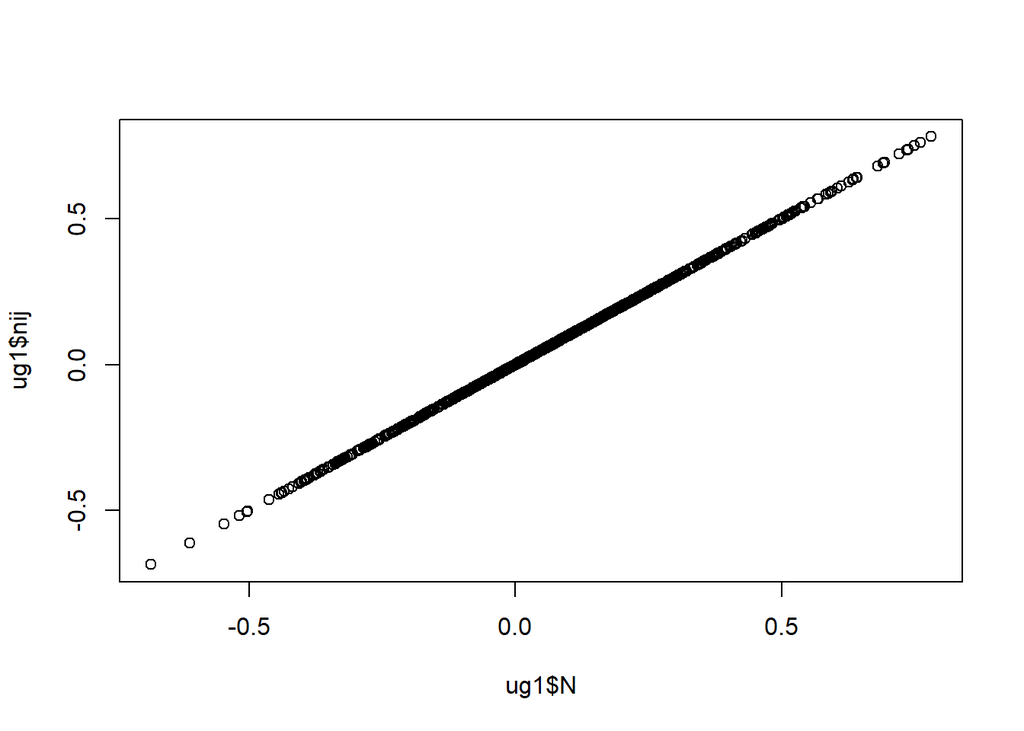

```r
   plot(ug1$N, ug1$nij)
```

**Uganda 2**: P and Q are presented in reverse scale (1 being best possible prior and 5 being worst possible prior) in the survey, but have been reversed in generating the raw data. Both P and Q are recoded so that Q > P means good news.

```r
# Uganda 2

# REVIEW

# According to PAP, prior is coded as 1 being best possible prior and 4 being worst
# possible prior:
# If you compare your LC5's record of managing its budget expenditures and
# contracting to other districts in Uganda how do you think it will compare?
# (1) much better, (2) better, (3) a little worse, (4) much worse, (8) don't
# know, (9) refused to answer

# PAP and MS (p 223) define P and Q as having the same 4-point scale, but the data
# suggest that budget.prior = 3 if response to prior questions is "don't know." See:
table(ug2$budget.prior, ug2$budget.prior.dontknow)
```

```
##
##        0    1
##   1 4772    0
##   2 9828    0
##   3    0 6474
##   4 9370    0
##   5 1326    0
```

```r
# Below we have changed the coding of m10 from previous version to account for the
# fact that higher values of budget.actual and budget.prior meant worse performance.

ug2$N_good <-with(ug2, ifelse(budget.actual > budget.prior |
                             (budget.actual== budget.prior & budget.actual>=4), 1,
                       ifelse(budget.actual < budget.prior |
                             (budget.actual== budget.prior & budget.actual<=2), 0, NA)))

# table(ug2$N_good, useNA = "a")

# Code P and Q
ug2$Q <- ug2$budget.actual
ug2$P <- ug2$budget.prior

if(reverse_uganda_2){
  ug2$Q  <- 6-ug2$Q
  ug2$P  <- 6-ug2$P
}

# Nij for Uganda 2 was calculated as Q - P, and because Q and P are coded
# in scale where 1 is best possible prior and 5 is for worse possible prior,
identical(ug2$nij,ug2$budget.actual-ug2$budget.prior)
```

```
## [1] TRUE
```

```r
# We regenerate Nij as
ug2$N <- ug2$budget.actual-ug2$budget.prior

#N_good # this would be the measure if we were to follow the median rule,
#but we decide to follow the definition given in the chapter
# ug2$N_good <- with(ug2, ifelse(Q > P | (Q==P & Q >= median(Q, na.rm = T)), 1,
#                         ifelse(Q < P | (Q==P & Q < median(Q, na.rm = T)), 0, NA)))

#Q_good (good news measure based entirely on median Q)
ug2$Q_good <- with(ug2, ifelse(Q >= median(Q, na.rm = T), 1,
                        ifelse(Q < median(Q, na.rm = T), 0, NA)))
```

# Metanalysis data

```r
  # Create P - Q graphing function

  # Load and append country data
  # files <- list.files("data/temp", pattern = "covinter", full.names = TRUE)
  # for (f in files) {
  #   load(f)
  # }

  # Metanalysis data
  madatpq <- rbind.fill(ben, brz, bf, mexsur, ug1, ug2)

  #standarize P and Q so that both P has mean 0 , sd 1 and Q normalized with same scaling
    madatpq <- madatpq %>%
    group_by(ctry) %>%
    mutate(
          Pi = (P - mean(P, na.rm = TRUE))/sd(P, na.rm = TRUE),
          Qi  = (Q - mean(P, na.rm = TRUE))/sd(P, na.rm = TRUE),
          Nchecki = Q - P,
          Nchecki = (Nchecki - mean(Nchecki, na.rm = TRUE))/sd(Nchecki, na.rm = TRUE )
          ) %>%
    ungroup()
```

# PQ plots

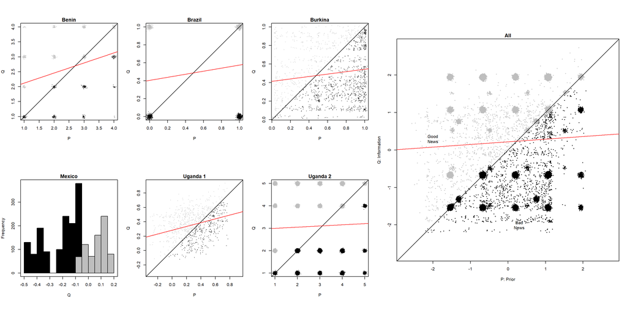

Grey circles indicate good news, black circles bad news. News is good if information exceeds priors, or if it confirms positive priors. No priors data is available for Mexico. Red line indicates linear fit between priors and information. For Uganda 1 there are some cases where news is classed as good even though the average priors across dimensions are higher than average information across dimensions since tie breaking rules were employed dimension by dimension. In the `All studies’ figure, $P$ and $Q$ have a common normalization such that priors are centered at 0 with a standard deviation of 1.

## Notes

- The value for P for Benin was inverted so that the scale now goes from worst possible prior/quality to best possible prior/quality, matching the coding of Q given. This harmonizes the interpretation of good and bad news in the PQ graphs with respect to the 45-degree line. It also creates some inconsistency with the presentation of these scales in the study chapters.
- Uganda 1 are generated using an aggregate measure of P created for the purpose of this analysis. Q is generated from the study aggregate measure of N in the study and the measure of P we constructed (Q = P + N). In order to ensure consistency of N values with the study, P and Q are not in the same scale, which results in goodnews not lying strictly above the 45-degree line and vice-versa.
- Uganda 2 appears to have a 1-5 scale for both P and Q, instead of 1-4 scale detailed in (MK p223).
- Mexico histogram shows values of Q, defined as the difference between the percentage of “unauthorized or misallocated spending, relative to municipalities within the same state that were governed by a different political party.” (MK p78)
- Burkina Faso has a skewed P distribution and this is why it looks like a block is shifted to one side in the all countries graph.

# `correct`: dichotomous indicator for correct recall of Q

# Uganda 2

m30 is in the same scale as information given (`budget.actual`). “Don’t know” answers are coded as 3 in line with Uganda 2 study.

```r
ug2$correct <- ifelse(ug2$m30==ug2$Q, 1,0)
ug2$post.prior.diff <- ug2$m30 - ug2$P
# ug2$post.prior.diff <- ifelse(ug2$N_good == 0, -ug2$post.prior.diff, ug2$post.prior.diff)
```

# Brazil:

m30 is already defined as whether posterior aligns with Q (information) (see 1a_prepdata.R). Difference between posterior and prior needs to be inverted so that positive differences means update toward better performance (m9-prior and m30 are both coded as 0 if account accepted and 1 if rejected).

```r
brz$correct <- brz$m30
brz$post.prior.diff <- brz$m9 - brz$m30 #inverted difference, see note above.
# brz$post.prior.diff <- ifelse(brz$N_good == 0, -brz$post.prior.diff, brz$post.prior.diff)
```

# Burkina

Recollection/attention check was administered to control only.

# Mexico:

Use existing m30 variable. The difference between posteriors and priors cannot be measured within subject due to lack of survey data administered pre-treatment.

```r
mexsur$correct <- mexsur$m30
```

# Benin

m30 scale (decreasing with quality) is inverted to match that of Q (increasing quality).

```r
ben$correct <- ifelse((5-ben$m30)==ben$Q,1,0)
ben$post.prior.diff <- (5-ben$m30) - ben$P
# ben$post.prior.diff <- ifelse(ben$N_good == 0, -ben$post.prior.diff, ben$post.prior.diff)
```

# Uganda 1

measure of m30 (SEE CONSTRUCTION OF MEASURE OF polknow_e BELOW) is substantively different from Q. See below. Difference between posteriors and priors here is coded directly from the measure of political knowledge (m30).

```r
# REVIEW
# STATA CODE
# *candsknown
# gen numcands_const = .
# replace numcands_const = 6 if code==18|code==16
# replace numcands_const = 5 if code==14
# replace numcands_const = 9 if code==19
# la var numcands_const "Number of candidates in constituency"
#
# egen numcandsknown_e = total(heardofcand_e), by(id)
# tab numcandsknown_e
# replace numcandsknown_e = . if core==.
# la var numcandsknown_e "Number of candidates named by respondent, EL"
# gen sharecandsknown_e = numcandsknown_e / numcands_const
# tab sharecandsknown_e, mi
# la var sharecandsknown_e "Share of primary candidates known, EL"
#
# gen sectorcorrectshr_e = numsectorcorrect_e / numcands_const
# la var sectorcorrectshr_e "Share of known cand priority sectors, EL"
#
# *Melina: note that BL measure is not comparable to EL measure since we changed T/F questions at EL (no variation in most T/F)
# egen mpresp_e = rowtotal (correct1 correct2 correct3 correct4 correct5 correct6)
# la var  mpresp_e "Know: Roles of MPs, EL"
# replace mpresp_e = . if core== .
# tab mpresp_e
# drop correct1 - correct6
#
# *Melina: Rescale such that variable is between 0 and 1. Min possible: -3. Max possible: +6
# gen mpresp_std_e = (mpresp_e - (-3)) / (6-(-3))
# tab mpresp_std_e
#
# *candsectorknow: Share of candidates for which a respondent can correctly name their priority sector.
# tab sector_e
# tab priority_c
# destring priority_c, replace
# gen sectorcorrect_e = 0
# replace sectorcorrect_e = 1 if priority_c == sector_e
# replace sectorcorrect_e = . if priority_c == . | priority_c == .d | priority_c == .r | sector_e == . | sector_e == .d | sector_e == .r |sector_e==-88
# la var sectorcorrect_e "Knows candidate's priority sector, EL"
#
# egen numsectorcorrect_e = total(sectorcorrect_e), by(id)
# replace numsectorcorrect_e = . if core_e == .
#
# tab numsectorcorrect_e if uniqueid == 1
# la var numsectorcorrect_e "Number of cand priority sector correctly named by resp, EL"
# replace numsectorcorrect_e = . if core_e == .
#
# gen sectorcorrectshr_e = numsectorcorrect_e / numcands_const
# la var sectorcorrectshr_e "Share of known cand priority sectors, EL"
#
# *Composite knowledge
# gen polknow_e = sectorcorrectshr_e + mpresp_std_e + sharecandsknown_e
# tab polknow_e if uniqueid==1, mi
# la var polknow_e  "Political knowledge, EL"

# Generate dichotomous variable for correct recollection in Uganda
# for values above and below the mean of the political knowledge scale (1.5)
ug1$correct <- ifelse(ug1$m30 >= 1.5, 1, 0)
# ug1$post.prior.diff <- ug1$m30
save(ug1, file="data/temp/ug1_covinter_clean.Rda")
```

# Save as `Rda` objects

```r
  save(mexsur, file = "data/temp/mex_covinter_clean.Rda")
  save(ug1,    file = "data/temp/ug1_covinter_clean.Rda")
  save(ug2,    file = "data/temp/ug2_covinter_clean.Rda")
  save(bf,     file = "data/temp/bf_covinter_clean.Rda")
  save(brz,    file = "data/temp/brz_covinter_clean.Rda")
  save(ben,    file = "data/temp/ben_covinter_clean.Rda")
```